# Assignment_9

Eric Taleghani

November 6, 2018

## Confounding Exercises

1. The proportion of women accepted is 0.3033351

```r
library(devtools)
#install_github("genomicsclass/dagdata")
library(dagdata)
data(admissions)

#male proportion
index = which(admissions$Gender==1)
accepted= sum(admissions$Number[index] * admissions$Percent[index]/100)
applied = sum(admissions$Number[index])
accepted/applied
```

```
## [1] 0.4451951
```

```r
#female proportion
index = which(admissions$Gender==0)
accepted= sum(admissions$Number[index] * admissions$Percent[index]/100)
applied = sum(admissions$Number[index])
accepted/applied
```

```
## [1] 0.3033351
```

2. The p value is 9.139e-22

```r
atab<-as.data.frame(matrix(0,2,2))
rownames(atab)<-c("Men","Women")
colnames(atab)<-c("Accepted","Rejected")
index = admissions$Gender==1
men=admissions[index,]
women=admissions[!index,]
atab[1,1]= sum(men$Number * men$Percent/100)
atab[1,2]= sum(men$Number*(1-men$Percent/100))
windex = which(admissions$Gender==0)
atab[2,1]= sum(women$Number * women$Percent/100)
atab[2,2]= sum(women$Number * (1-women$Percent/100))
atab
```

```
##       Accepted Rejected
## Men    1198.02  1492.98
## Women   556.62  1278.38
```

```r
chisq.test(atab)$p.value
```

```
## [1] 9.139492e-22
```

3. The hardest major is F.
4. The proportion accepted to the hardest major is 0.06477591

```r
major = admissions[1:6,1]
men = admissions[1:6,]
women =admissions[7:12,]
H = (men$Number*men$Percent/100 + women$Number*women$Percent/100) / (men$Number+women$Number)
H
```

```
## [1] 0.64315113 0.63213675 0.35062092 0.33946970 0.25308219 0.06477591
```

```r
major[which.min(H)]
```

```
## [1] F
## Levels: A B C D E F
```

```r
min(H)
```

```
## [1] 0.06477591
```

5. For men, the correlation between the number of applications across majors and H is 0.7647567

```r
cor(H,men$Number)
```

```
## [1] 0.7647567
```

6. For women, the correlation between the number of applications across majors and H is -0.6743393

```r
cor(H,women$Number)
```

```
## [1] -0.6743393
```

7. Option C: There is confounding between genders and preference for “hard” majors: females are more likely to apply to harder majors.

## Gene Expression Data Exercises

```r
library(devtools)
#install_github("genomicsclass/GSE5859")
library(Biobase)
library(GSE5859)
data(GSE5859)

geneExpression = exprs(e)
sampleInfo = pData(e)

year = format(sampleInfo$date,"%y")
length( unique(year) )
```

```
## [1] 5
```

```r
table(year,sampleInfo$ethnicity)
```

```
##
## year ASN CEU HAN
##   02   0  32   0
##   03   0  54   0
##   04   0  13   0
##   05  80   3   0
##   06   2   0  24
```

2. There are two years in which more than one ethnicity is represented.

```r
tab=table(year,sampleInfo$ethnicity)
print(tab)
```

```
##
## year ASN CEU HAN
##   02   0  32   0
##   03   0  54   0
##   04   0  13   0
##   05  80   3   0
##   06   2   0  24
```

```r
x=rowSums(tab!=0)
sum(x>=2)
```

```
## [1] 2
```

3. The proportion of values with more than one ethnicity represented is 0.04761905

```r
month.year = format(sampleInfo$date,"%m%y")
tab=table(month.year,sampleInfo$ethnicity)
print(tab)
```

```
##
## month.year ASN CEU HAN
##       0103   0  27   0
##       0203   0  18   0
##       0205   0   2   0
##       0303   0   7   0
##       0403   0   2   0
##       0404   0   4   0
##       0406   0   0  24
##       0505   2   0   0
##       0605  22   1   0
##       0606   2   0   0
##       0705   6   0   0
##       0805  12   0   0
##       0905   6   0   0
##       1002   0   2   0
##       1005  16   0   0
##       1102   0  15   0
##       1104   0   7   0
##       1105  13   0   0
##       1202   0  15   0
##       1204   0   2   0
##       1205   3   0   0
```

```r
myx=rowSums(tab!=0)
mean(myx>=2)
```

```
## [1] 0.04761905
```

4. 4308 genes have a q-value less than 0.05
5. The estimate of pi0 provided by qvalue is 0.3628642

```r
library(qvalue)
library(genefilter)
year = factor( format(sampleInfo$date,"%y") )
index = which(year%in% c("02","03") & sampleInfo$ethnicity=="CEU")
year = droplevels(year[index])
pval = rowttests(geneExpression[ ,index], year)$p.value
qval = qvalue(pval)
sum(qval$qvalue < 0.05)
```

```
## [1] 4308
```

```r
qval$pi0
```

```
## [1] 0.3628642
```

6. 2463 genes have a q-value less than 0.05

```r
year = factor( format(sampleInfo$date,"%y") )
index = which(year%in% c("03","04") & sampleInfo$ethnicity=="CEU")
year = droplevels(year[index])
pval = rowttests(geneExpression[ ,index], year)$p.value
qval = qvalue(pval)
sum(qval$qvalue < 0.05)
```

```
## [1] 2463
```

7. 7217 genes have a q-value less than 0.05

```r
ethnicity = factor( sampleInfo$ethnicity)
index = which(ethnicity%in% c("CEU","ASN"))
ethnicity = droplevels(ethnicity[index])
pval = rowttests(geneExpression[ ,index], ethnicity)$p.value
qval = qvalue(pval)
sum(qval$qvalue < 0.05)
```

```
## [1] 7217
```

8. The number of gees with q-values less than 0.05 dropped to 560 when only analyzing the samples processed in 2005.

```r
ethnicity = factor( sampleInfo$ethnicity)
year = factor( format(sampleInfo$date,"%y") )
index = which(ethnicity%in% c("CEU","ASN") & year=="05")
ethnicity = droplevels(ethnicity[index])
pval = rowttests(geneExpression[ ,index], ethnicity)$p.value
qval = qvalue(pval)
sum(qval$qvalue < 0.05)
```

```
## [1] 560
```

```r
table(sampleInfo$ethnicity[index])
```

```
##
## ASN CEU HAN
##  80   3   0
```

9. 3695 genes have q-values less tha 0.05.

```r
ethnicity = factor( sampleInfo$ethnicity)
year = factor( format(sampleInfo$date,"%y") )
indexASN = which(ethnicity%in% c("ASN") & year=="05")
indexCEU = which(ethnicity%in% c("CEU") & year=="02")
set.seed(3)
indexCEU<-sample(indexCEU,3)
index<-c(indexASN,indexCEU)
ethnicity = droplevels(ethnicity[index])
pval = rowttests(geneExpression[ ,index], ethnicity)$p.value
qval = qvalue(pval)
sum(qval$qvalue < 0.05)
```

```
## [1] 3695
```

## Adjusting for Batch Effects with Linear Models Exercises

1. 59 genes have q-values less than 0.1

```r
#install_github("genomicsclass/GSE5859Subset")
library(Biobase)
library(GSE5859Subset)
library(qvalue)
library(genefilter)
data(GSE5859Subset)

sex = sampleInfo$group
month = factor( format(sampleInfo$date,"%m"))
table( sampleInfo$group, month)
```

```
##    month
##     06 10
##   0  9  3
##   1  3  9
```

```r
sex = factor(sex)
pval = rowttests(geneExpression, sex)$p.value
qval = qvalue(pval)
sum(qval$qvalue < 0.1)
```

```
## [1] 59
```

2. The proportion of genes on chrX or chrY is 0.3389831
3. 8 of the genes are on chrY

```r
sex = factor( sex)
pval = rowttests(geneExpression, sex)$p.value
qval = qvalue(pval)
qvals = qval$qvalues
index = geneAnnotation$CHR[qvals<0.1]%in%c("chrX","chrY")
prop = mean(index)
total = length(geneAnnotation$CHR)

indexY = geneAnnotation$CHR[qvals<0.1]%in%c("chrY")
table(indexY)["TRUE"]
```

```
## TRUE
##    8
```

4. The proportion with p values less than 0.05 is 0.8717949

```r
sex = factor( sex)
pval = rowttests(geneExpression, sex)$p.value
qval = qvalue(pval)
qvals = qval$qvalues
index = which(qvals<0.1 & !geneAnnotation$CHR%in%c("chrX","chrY"))
month = factor( format(sampleInfo$date,"%m"))
pval = rowttests(geneExpression[index,], month)$p.value
mean(pval<0.05)
```

```
## [1] 0.8717949
```

5. Option D creates the appropriate design matrix

```r
X = model.matrix(~sex+month)
X
```

```
##    (Intercept) sex1 month10
## 1            1    1       0
## 2            1    1       0
## 3            1    1       0
## 4            1    1       1
## 5            1    1       1
## 6            1    1       1
## 7            1    1       1
## 8            1    1       1
## 9            1    1       1
## 10           1    1       1
## 11           1    1       1
## 12           1    1       1
## 13           1    0       0
## 14           1    0       0
```

[output cut: 18 more lines]

6. 17 q values are now less than 0.1

```r
X = model.matrix(~sex+month)
i = 234
y = geneExpression[i,]
fit = lm(y~X-1)
summary(fit)$coef
```

```
##                 Estimate Std. Error     t value     Pr(>|t|)
## X(Intercept)  9.33316105 0.06098459 153.0412990 1.714250e-33
## Xsex1        -0.04281057 0.09220004  -0.4643227 6.471942e-01
## Xmonth10      0.25352885 0.09220004   2.7497696 1.200505e-02
```

```r
pvals <- t( sapply(1:nrow(geneExpression),function(j){
  y <- geneExpression[j,]
  fit <- lm(y~X-1)
  summary(fit)$coef[2,4]
} ) )

qval = qvalue(pvals)
qvals = qval$qvalues
sum(qvals<0.1)
```

```
## [1] 17
```

7. Now the proportion of genes on chrX or chrY is 0.8823529
8. There are 15 genes on chr X or chrY

```r
index = geneAnnotation$CHR[qvals<0.1]%in%c("chrX","chrY")
prop = mean(index)
prop
```

```
## [1] 0.8823529
```

```r
table(index)["TRUE"]
```

```
## TRUE
##   15
```

9. there are 3170 q values from the month comparison less than 0.1

```r
X = model.matrix(~sex+month)
pvals <- t( sapply(1:nrow(geneExpression),function(j){
  y <- geneExpression[j,]
  fit <- lm(y~X-1)
  summary(fit)$coef[3,4] # third coef, for month
} ) )
library(qvalue)
library(genefilter)
qval = qvalue(pvals)
qvals = qval$qvalues
sum(qvals<0.1)
```

```
## [1] 3170
```

## Factor Analaysis Exercises

1. Option B
2. Option C
3. Option D: The fact that in the plot ordered by month we see two groups mainly driven by month, and within these we see subgroups driven by date, seems to suggest date more than month per se are the hidden factors.

```r
y = geneExpression - rowMeans(geneExpression)

library(RColorBrewer)
library(rafalib)
```

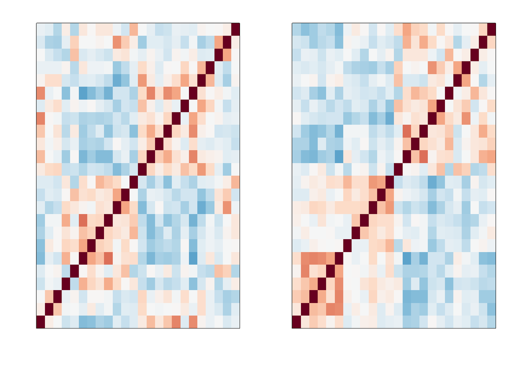

```r
mypar(1,2)
n=ncol(y)
cors=cor(y)
cols=colorRampPalette(rev(brewer.pal(11,"RdBu")))(100)
image(1:n,1:n,cors,xaxt="n",yaxt="n",col=cols,xlab="",ylab="",zlim=c(-1,1))
o <- order(sampleInfo$date)
yo<-y[,o]
cors=cor(yo)
cols=colorRampPalette(rev(brewer.pal(11,"RdBu")))(100)
image(1:n,1:n,cors,xaxt="n",yaxt="n",col=cols,xlab="",ylab="",zlim=c(-1,1))
```

4. Option B gives you the estimates

```r
s <- svd(y)
pcs <- s$v[,1:2] #gives first 2 PCs
rownames(pcs)<-colnames(y)
round(pcs,2)
```

```
##                   [,1]  [,2]
## GSM136508.CEL.gz -0.23 -0.02
## GSM136530.CEL.gz -0.03 -0.14
## GSM136517.CEL.gz -0.08 -0.19
## GSM136576.CEL.gz  0.31 -0.07
## GSM136566.CEL.gz  0.00  0.18
## GSM136574.CEL.gz  0.35 -0.09
## GSM136575.CEL.gz  0.23 -0.07
## GSM136569.CEL.gz  0.22 -0.02
## GSM136568.CEL.gz  0.29  0.00
## GSM136559.CEL.gz  0.15  0.43
## GSM136565.CEL.gz  0.11  0.23
## GSM136573.CEL.gz  0.22  0.04
## GSM136523.CEL.gz -0.14 -0.21
## GSM136509.CEL.gz -0.28  0.03
## GSM136727.CEL.gz -0.38  0.42
## GSM136510.CEL.gz -0.22 -0.05
## GSM136515.CEL.gz -0.20 -0.09
## GSM136522.CEL.gz -0.04 -0.20
## GSM136507.CEL.gz -0.29  0.00
## GSM136524.CEL.gz -0.11 -0.35
## GSM136514.CEL.gz -0.01 -0.30
## GSM136563.CEL.gz -0.03  0.20
## GSM136564.CEL.gz  0.08  0.35
## GSM136572.CEL.gz  0.10 -0.07
```

```r
fit = s$u[,1:2]%*% (s$d[1:2]*t(pcs))
var(as.vector(fit))/var(as.vector(y))
```

```
## [1] 0.3394245
```

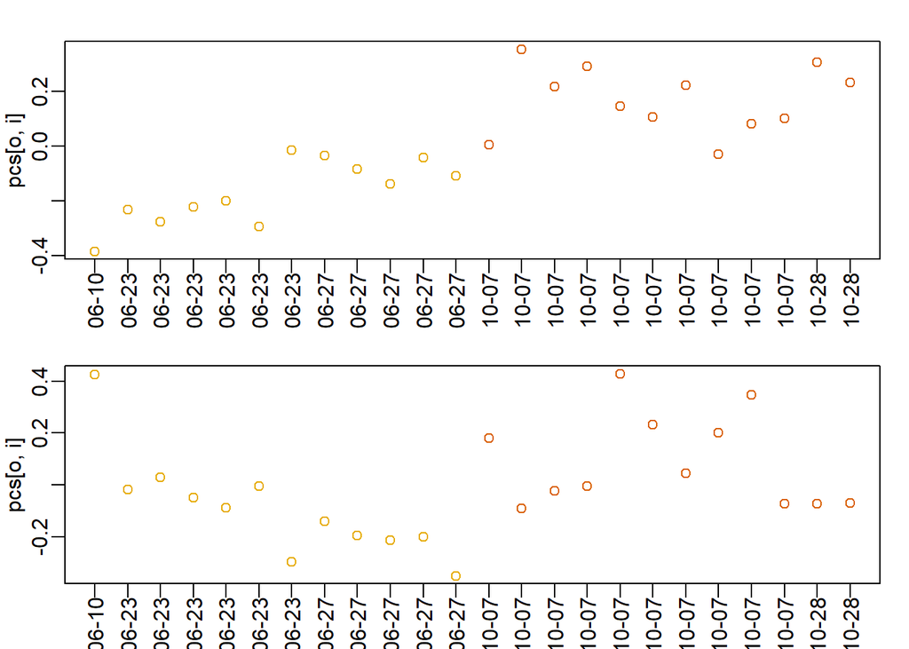

```r
month=format(sampleInfo$date, "%m")
pcs = svd(y)$v[,1:2]
o = order(sampleInfo$date)
cols = as.numeric(month)[o]
mypar(2,1)
for(i in 1:2){
  plot(pcs[o,i],col=cols,xaxt="n",xlab="")
  label = gsub("2005-","",sampleInfo$date[o])
  axis(1,1:ncol(y),label,las=2)
}
```

6. 2 principle components explain more than 10% each of the variability

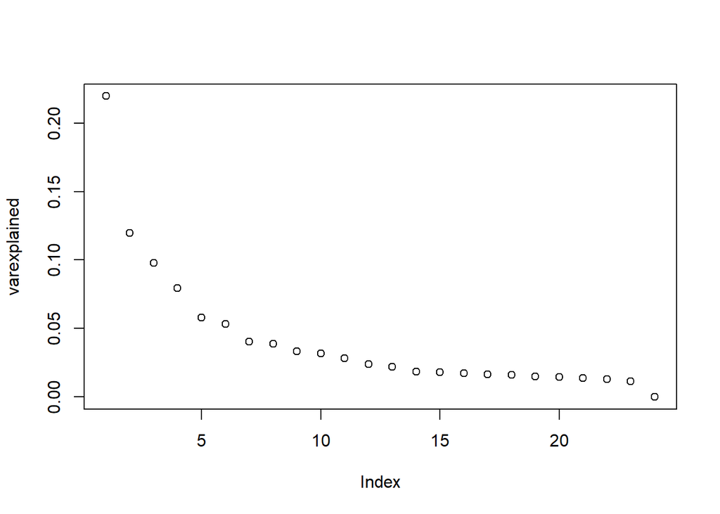

```r
s = svd(y)
varexplained = s$d^2/ sum(s$d^2)
plot(varexplained)
```

```r
sum(varexplained>0.10)
```

```
## [1] 2
```

7. The first principle component correlates most with month
8. This correlation is 0.8297915

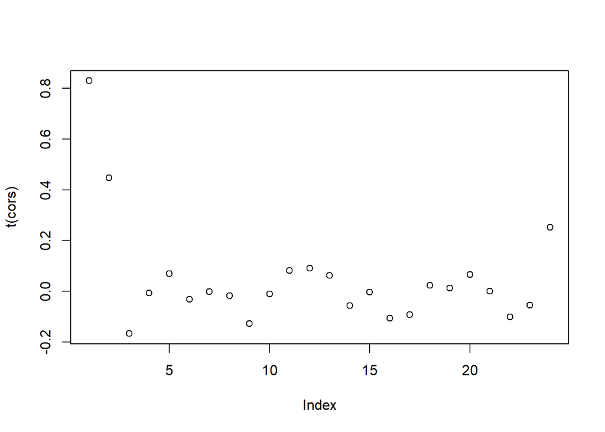

```r
s = svd(y)
month = factor( format(sampleInfo$date,"%m"))
cors = cor( as.numeric(month),s$v)
plot(t(cors))
```

```r
which.max(abs(cors))
```

```
## [1] 1
```

```r
max(abs(cors))
```

```
## [1] 0.8297915
```

9. The first principle component most correlates with sex
10. This correlation is 0.6236858

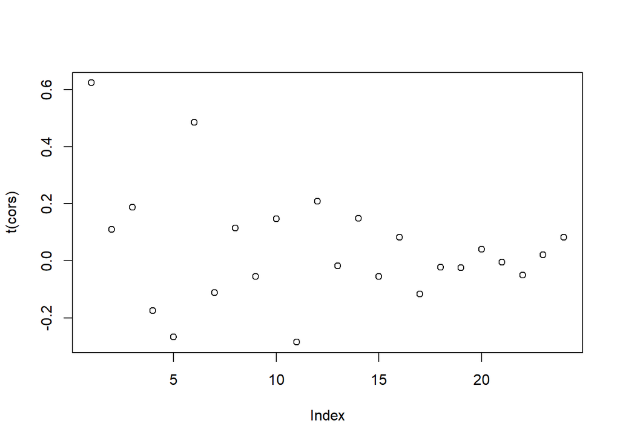

```r
s = svd(y)
sex = sampleInfo$group
cors = cor( as.numeric(sex),s$v)
plot(t(cors))
```

```r
which.max(abs(cors))
```

```
## [1] 1
```

```r
max(abs(cors))
```

```
## [1] 0.6236858
```

11. For the sex comparison, there are 14 q values less than 0.1
12. The proportion is 1, indicating that they are all located on chrX or chrY

```r
X <- model.matrix(~sex+s$v[,1:2])

library(limma)
X <- model.matrix(~sex+s$v[,1:2])
fit <- lmFit(y,X)
k <- 2 ##second coef, for month
ses <- fit$stdev.unscaled[,k]*fit$sigma
ttest <- fit$coef[,k]/ses
pvals <- 2*pt(-abs(ttest),fit$df)
library(qvalue)
library(genefilter)
qval = qvalue(pvals)
qvals = qval$qvalues
sum(qvals<0.1)
```

```
## [1] 14
```

```r
index = geneAnnotation$CHR[qvals<0.1]%in%c("chrX","chrY")
mean(index)
```

```
## [1] 1
```

## Surrogate Variable Analysis Exercises

1. 13 genes have a q value less than 0.1

```r
library(sva)
library(Biobase)

s <- svd(geneExpression-rowMeans(geneExpression))
cor(sampleInfo$group,s$v[,1])
```

```
## [1] 0.6236858
```

```r
sex = sampleInfo$group
mod = model.matrix(~sex)
svafit = sva(geneExpression,mod)
```

```
## Number of significant surrogate variables is:  5
## Iteration (out of 5 ):1  2  3  4  5
```

```r
head(svafit$sv)
```

```
##             [,1]        [,2]        [,3]       [,4]         [,5]
## [1,] -0.26862626 -0.03838109  0.15306742 -0.3007374  0.210098158
## [2,] -0.06132157 -0.15755769 -0.03538763  0.0851655 -0.063869257
## [3,] -0.12161818 -0.21766433 -0.12624414  0.2443445 -0.099004174
## [4,]  0.30660574 -0.09657648 -0.32034135 -0.1680430  0.620260643
## [5,] -0.01850853  0.18648507  0.17931970  0.4244993 -0.007840835
## [6,]  0.36062840 -0.08542758 -0.10726746  0.1074114  0.033204590
```

```r
for(i in 1:ncol(svafit$sv)){
print( cor(s$v[,i],svafit$sv[,i]) )
}
```

```
## [1] 0.9944755
## [1] 0.9964202
## [1] -0.9915972
## [1] -0.9896597
## [1] -0.9518427
```

```r
svaX<-model.matrix(~sex+svafit$sv)
library(limma)
fit <- lmFit(geneExpression,svaX)
k <- 2 #second coef, for sex
ses <- fit$stdev.unscaled[,k]*fit$sigma
ttest <- fit$coef[,k]/ses
pvals <- 2*pt(-abs(ttest),fit$df)
qval = qvalue(pvals)
qvals = qval$qvalues
sum(qvals<0.1)
```

```
## [1] 13
```

2. 12 of these genes are on chrX and chrY

```r
index = geneAnnotation$CHR[qvals<0.1]%in%c("chrX","chrY")
table(index)["TRUE"]
```

```
## TRUE
##   12
```